# STA 506 Final Examination

Grace Lippert

Due: May 5, 2026

## **Final Exam Guidelines**

- **Coverage**: The major concepts and inference procedures—such as sampling distributions, confidence intervals, and hypothesis testing—are covered and implemented using both classical parametric likelihood-based methods and modern non-parametric approaches, including the bootstrap and kernel density estimation.
- **Part A** requires derivation of selected likelihood-based functions for performing various types of inference, with sufficient detail to enable translation of these derivations into code for numerical analysis.
- Your code for the problems in **Part B** must align with your derivations in **Part A** and be well commented where necessary.
- In **Part B**, all numerical results must be interpreted from a practical perspective.

## **Policies of Using AI Tools**

- **Policy on AI Tool Use**: Students must adhere to the AI tool policy specified in the course syllabus. The direct copying of AI-generated content is strictly prohibited. All submitted work must reflect your own understanding; where external tools are consulted, content must be thoroughly rephrased and synthesized in your own words.
- **Code Inclusion Requirement**: Any code included in your essay must be properly commented to explain the purpose and/or expected output of key code lines. Submitting AI-generated code without meaningful, student-added comments will not be accepted.

## **Working Model for the Final Exam**

**Caution**: *Please follow the suggested expressions and guided steps to complete the exam. Other approaches such as transformation for trivialize the problems that will not meet the exam objectives.*

The **Kumaraswamy distribution** is a two-parameter continuous probability distribution defined on the interval (0, 1). It is often used as an alternative to the Beta distribution due to its simple closed-form expressions for the cumulative distribution function (CDF) and quantile function. It is commonly used in

- **Hydrology**: Modeling rainfall, streamflow, or other bounded natural phenomena
- **Economics**: Income shares, proportions, or bounded indices
- **Monte Carlo simulation**: Efficient random variate generation (via inverse transform)
- **Machine learning**: Output layer for bounded targets, prior distributions in Bayesian models
- **Reliability engineering**: Modeling failure rates of systems with bounded lifetimes

Let $X$ be the Kumaraswamy random variable with Cumulative Distribution Function (CDF)

$$F(x; a, b) = 1 - (1 - x^a)^b$$

where $a > 0$ and $b > 0$ unknown parameters and $0 < x < 1$.

The following are two special case of the Kumaraswamy distribution:

1. **Uniform Distribution**: When $a = 1$ and $b = 1$, the Kumaraswamy distribution becomes a uniform distribution over $[0, 1]$ with CDF $F(x) = x$.
2. **Power Distribution**: when $b = 1$ and $a > 0$, the Kumaraswamy distribution becomes a power distribution over $[0, 1]$ with CDF $F(x) = x^a$.

This final exam focuses on inferences of Kumaraswamy distribution and related data analysis.

## Part A: Methodological Derivations

### **Problem A1**:

Show that the density function of the Kumaraswamy distribution is

$$f(x; a, b) = ab \, x^{a-1} (1 - x^a)^{b-1}.$$

# Answer to Problem A1:

We can determine the derivative of the CDF function of the Kumaraswany distribution to find the density function. We know that the CDF is $F(x; a, b) = 1 - (1 - x^a)^b$, therefore $f(x;a,b)$ is:

$$\begin{aligned}
f(x;a,b) &=\frac{d}{dx}F(x;a,b) \\
&=\frac{d}{dx}[1 - (1 - x^a)^b] \\
&= b(1-x^a)^{b-1}(ax^{a-1})
\end{aligned}$$

Therefore the density function of the Kumaraswamy distribution is:

$$f(x; a, b) = ab \, x^{a-1} (1 - x^a)^{b-1}$$

### **Problem A2**:

Let $\{x_1, x_2, \cdots, x_n \}$ be an i.i.d. random sample taken from a population that follows the aove 2-parameter Kumaraswamy distribution. Write out the loglikelihood function of $a$ and $b$, denoted by $\ell(a,b)$, based on the above random sample and **derive** the gradient vector $[\ell_a^\prime(a,b), \ell_b^\prime(a,b)]$, the first order partial derivative of the log-likelihood with respect to parameters $a$ and $b$.

# Answer to Problem A2:

To find the loglikelihood function of the Kumaraswamy distribution we can start by finding the likelihood function:

$$L(a,b)=\prod_{i=1}^nf(x_i;a, b)=\prod_{i=1}^n ab \, x_i^{a-1} (1 -
x_i^a)^{b-1}$$

Then we can find the loglikelihood function:

$$\begin{aligned}
\ell(a,b)&=\ln(L(a,b))=\ln \left[\prod_{i=1}^n ab \,x_i^{a-1} (1 -
x_i^a)^{b-1}\right] \\
&= \sum_{i=1}^n \left[ \ln(a)+\ln(b)+(a-1)\ln(x_i)+(b-1)\ln(1-x_i^a)
\right] \\
&= n\ln (a)+n\ln (b)+(a-1)\sum_{i=1}^n \ln(x_i) +(b-1)\sum_{i=1}^n
\ln(1-x_i^a)
\end{aligned}$$

We can then derive the gradient vector $[\ell_a^\prime(a,b), \ell_b^\prime(a,b)]$, the first order partial derivatives of the log-likelihood with respect to parameters $a$ and $b$:

$$\begin{aligned}
\ell_a^\prime(a,b) &= \frac{\partial\ell}{\partial a}\left[n\ln
(a)+n\ln (b)+(a-1)\sum_{i=1}^n \ln(x_i) +(b-1)\sum_{i=1}^n \ln(1-x_i^a)
\right] \\
&=
\frac{n}{a}+\sum_{i=1}^n\ln(x_i)-(b-1)\sum_{i=1}^n\frac{x_i^a\ln(x_i)}{1-x_i^a}
\end{aligned}$$

$$\begin{aligned}
\ell_b^\prime(a,b) &= \frac{\partial\ell}{\partial b}\left[n\ln
(a)+n\ln (b)+(a-1)\sum_{i=1}^n \ln(x_i) +(b-1)\sum_{i=1}^n \ln(1-x_i^a)
\right] \\
&= \frac{n}{b}+\sum_{i=1}^n\ln(1-x_i^a)
\end{aligned}$$

Therefore the gradient vector is:

$$[\ell_a^\prime(a,b),
\ell_b^\prime(a,b)]=\left[\frac{n}{a}+\sum_{i=1}^n\ln(x_i)-(b-1)\sum_{i=1}^n\frac{x_i^a\ln(x_i)}{1-x_i^a}
\, , \, \frac{n}{b}+\sum_{i=1}^n\ln(1-x_i^a) \right]$$

### **Problem A3**:

Based on the gradients functions obtained in the above problem A2, **derive** the observed Fisher Information matrix (i.e, the negative Hessian Matrix).

# Answer to Problem A3:

We can derive the Fisher Information matrix by first finding the Hessian Matrix and taking the negative of it.

First we will find $\frac{\partial^2 \ell}{\partial a^2}$, $\frac{\partial^2 \ell}{\partial b^2}$, and $\frac{\partial^2 \ell}{\partial a \partial b}$:

$$\begin{aligned}
\frac{\partial^2 \ell}{\partial a^2} &= \frac{\partial
\ell}{\partial a} \left[
\frac{n}{a}+\sum_{i=1}^n\ln(x_i)-(b-1)\sum_{i=1}^n\frac{x_i^a\ln(x_i)}{1-x_i^a}
\right] \\
&=-\frac{n}{a^2}-(b-1)\sum_{i=1}^n \frac{x_i^a(\ln
x_i)^2(1-x_i^a)-(x_i^a\ln x_i)(-x_i^a \ln x_i)}{(1-x_i^a)^2} \\
&= -\frac{n}{a^2}-(b-1)\sum_{i=1}^n \frac{x_i^a (\ln
x_i)^2}{(1-x_i^a)^2}
\end{aligned}$$

$$\begin{aligned}
\frac{\partial^2\ell}{\partial b^2} &= \frac{\partial \ell}{\partial
b} \left[ \frac{n}{b}+\sum_{i=1}^n\ln(1-x_i^a) \right] \\
&= -\frac{n}{b^2}
\end{aligned}$$

$$\begin{aligned}
\frac{\partial^2 \ell}{\partial a \partial b} &= \frac{\partial
\ell}{\partial b} \left[
\frac{n}{a}+\sum_{i=1}^n\ln(x_i)-(b-1)\sum_{i=1}^n\frac{x_i^a\ln(x_i)}{1-x_i^a}\right]
\\
&= \sum_{i=1}^n\frac{x_i^a\ln(x_i)}{1-x_i^a}
\end{aligned}$$

Therefore, the Hessian matrix is:

$$\begin{aligned}
\mathcal{H}(a, b) &=
\begin{bmatrix}
\frac{\partial^2 \ell}{\partial a^2} & \frac{\partial^2
\ell}{\partial a \partial b} \\
\frac{\partial^2 \ell}{\partial b \partial a} &
\frac{\partial^2\ell}{\partial b^2}
\end{bmatrix} \\
&= \begin{bmatrix}
-\frac{n}{a^2}-(b-1)\sum_{i=1}^n \frac{x_i^a (\ln x_i)^2}{(1-x_i^a)^2}
& \sum_{i=1}^n\frac{x_i^a\ln(x_i)}{1-x_i^a} \\
\sum_{i=1}^n\frac{x_i^a\ln(x_i)}{1-x_i^a} & -\frac{n}{b^2}
\end{bmatrix}
\end{aligned}$$

Therefore, the Fisher Information matrix is:

$$\begin{aligned}
\mathcal{J}_n(a, b) &= -\mathcal{H}(a,b) \\
&= -
\begin{bmatrix}
-\frac{n}{a^2}-(b-1)\sum_{i=1}^n \frac{x_i^a (\ln x_i)^2}{(1-x_i^a)^2}
& \sum_{i=1}^n\frac{x_i^a\ln(x_i)}{1-x_i^a} \\
\sum_{i=1}^n\frac{x_i^a\ln(x_i)}{1-x_i^a} & -\frac{n}{b^2}
\end{bmatrix}
\end{aligned}$$

### **Problem A4**:

Consider power distribution $F(x) = x^a, (a >0 \quad \text{ and }\quad x \in (0,1))$, a special case of the Kumaraswamy distribution with $b = 1$, and a random sample from this distribution $\{ x_1, x_2, \cdots, x_n\}$. **Derive** the MLE and MME of $a$ respectively. [*Hint: To find the MME, you need to compute the moment of the power distribution; that is, $E[X^k] = \int_0^1 x^k F'(x) dx$. Note that both the MLE and the MME have closed-form expressions.*]

# Answer to Problem A4:

In order to find the MLE of the power distribution we must first find the density function using the CDF:

$$f(x;a)=F'(x;a)=\frac{d}{dx}\left[ x^a\right]=ax^{a-1}$$

We can then determine the likelihood function:

$$L(a)=\prod_{i=1}^nf(x_i;a)=\prod_{i=1}^nax_i^{a-1}$$

Next we can determine the loglikelihood function:

$$\ell(a)=\ln[L(a)]=n\ln a+(a-1)\sum_{i=1}^n\ln x_i$$

Next we can find the partial derivative with respect to $a$:

$$\frac{\partial\ell}{\partial a}=\frac{n}{a}+\sum_{i=1}^n\ln x_i$$

Finally, we can set the partial derivative equal to 0 and solve for $a$ in order to determine an MLE function that can be used to estimate $\hat{a}$

$$\begin{aligned}
&\quad \; \: \frac{\partial\ell}{\partial a}=0 \\
&\Rightarrow \frac{n}{a}+\sum_{i=1}^n\ln x_i =0 \\
&\Rightarrow \frac{n}{a}=-\sum_{i=1}^n\ln x_i \\
&\Rightarrow a=-\frac{n}{\sum_{i=1}^n\ln x_i}
\end{aligned}$$

Therefore our MLE function is:

$$\hat{a}_{MLE}=\frac{n}{-\sum_{i=1}^n\ln x_i}$$

Next we will determine the MME function for the power distribution. We will start by finding the first population moment of the power distribution:

$$\begin{aligned}
\mu_1 &= \mathbb{E}[X] \\
&=\int_0^1x F'(x) dx \\
&= \int_0^1 x (ax^{a-1})dx \\
&= a\int_0^1x^adx \\
&= \frac{a}{a+1}
\end{aligned}$$

We can then determine the corresponding sample moment:

$$m_1 = \frac{1}{n}\sum_{i=1}^{n}{X_i}$$

Finally, we can set these equal to each other and solve for $a$ to determine the MME function that can be used to estimate $\hat{a}$:

$$\begin{aligned}
m_1=\frac{a}{a+1} \Rightarrow a=\frac{m_1}{1-m_1}
\end{aligned}$$

Therefore our MME function is:

$$\hat{a}_{MME}=\frac{\frac{1}{n}\sum_{i=1}^{n}{x_i}}{1-\frac{1}{n}\sum_{i=1}^{n}{x_i}}$$

### **Problem A5**:

Using the same setting as in **Problem A4**, find the asymptotic (Wald) confidence interval for $a$. [*Hint: Compute the Fisher information for $a$, then take its reciprocal to obtain the variance*.]

# Answer to Problem A5:

To find the asymptotic (Wald) confidence interval for this setting we will start by computing the Fisher information for $a$. As we determined above, the first partial derivative of the loglikelihood function with respect to $a$ for this setting is:

$$\frac{\partial\ell}{\partial a}=\frac{n}{a}+\sum_{i=1}^n\ln x_i$$

We can take the second partial derivative with respect to $a$ in order to determine with Fisher information:

$$\frac{\partial^2\ell}{\partial a^2}=\frac{\partial \ell}{\partial a}
\left[\frac{n}{a}+\sum_{i=1}^n\ln x_i \right] = -\frac{n}{a^2}$$

Therefore the Fisher information is:

$$\mathcal{J}_n(a)=-\frac{\partial^2\ell}{\partial a^2}=\frac{n}{a^2}$$

This can be used to find the estimated asymptotic variance and standard deviation:

$$\begin{aligned}
\widehat{\text{Var}}(\hat{a}) &\approx
\mathcal{J}_n(\hat{a})^{-1}=\frac{\hat{a}^2}{n} \\
\widehat{SE}(\hat{a}) &=\sqrt{\widehat{\text{Var}}(\hat{a})} \approx
\frac{\hat{a}}{\sqrt{n}}
\end{aligned}$$

This can be used to determine the asymptotic (Wald) confidence interval:

$$\hat{a} \pm z_{1-\alpha/2} \frac{\hat{a}}{\sqrt{n}}$$

Where the $z$ is from the standard normal distribution and the $\alpha$ is the predetermined confidence level.

### **Problem A6**:

Using the same setting as in **Problem A4**, perform a likelihood ratio test for the hypothesis $H_0 :a=1$ (i.e., the power distribution reduces to a uniform distribution). [*Hint: Evaluate the log-likelihood function at the maximum likelihood estimate $\hat{a}$ and at $a=1$, then use these values to construct the LRT test statistic.*]

# Answer to Problem A6:

In order to perform a likelihood ratio test for the hypothesis $H_0: a=1$ we will start by evaluating our previously determined loglikelihood function at $\hat{a}$ and $a=1$. Our loglikelihood function is below:

$$\ell(a)=n\ln a+(a-1)\sum_{i=1}^n\ln x_i$$

Plugging in $\hat{a}$:

$$\ell(\hat{a})=n\ln \hat{a}+(\hat{a}-1)\sum_{i=1}^n\ln x_i$$

Plugging in $a=1$:

$$\ell(1)=n\ln 1+(1-1)\sum_{i=1}^n\ln x_i=0$$

Therefore the test statistic for this setting is:

$$\begin{aligned}
Λ &=-2[\ell(1)-\ell(\hat{a})] \\
&=-2\left[0-n\ln \hat{a}-(\hat{a}-1)\sum_{i=1}^n\ln x_i\right] \\
&=2n\ln \hat{a}+2(\hat{a}-1)\sum_{i=1}^n\ln x_i
\end{aligned}$$

From here we can set up a formal hypotheses test. Our null and alternative hypotheses are:

Then we can determine our critical value. That is, we will reject $H_0$ if:

$$Λ=2n\ln \hat{a}+2(\hat{a}-1)\sum_{i=1}^n\ln x_i > \chi_{1,1-\alpha}^2$$

Where $\alpha$ is a predetermined confidence level.

If our test statistic $Λ$ is greater than our critical value of $\chi_{1,1-\alpha}^2$ then we will have enough evidence to reject our null hypothesis $H_0: a=1$. If our test statistic is not greater than our critical value then we will fail to reject the null hypothesis.

## Part B: Numerical Analysis

**All code must be well commented and adhere to best coding practices**

**Working Dataset**: A small reservoir supplies water to a town. During the dry season (50 days), engineers record the fraction of usable storage filled each morning. Values near 0 mean the reservoir is nearly empty; values near 1 mean it’s full. The distribution tends to be right‑skewed (mostly low levels due to drought) but with occasional replenishment.

The following 50 data points (ordered for clarity) represent the daily proportion of usable storage:

```
0.12, 0.14, 0.15, 0.16, 0.17, 0.18, 0.19, 0.20, 0.21, 0.22,
0.23, 0.24, 0.25, 0.26, 0.27, 0.28, 0.29, 0.30, 0.31, 0.32,
0.33, 0.34, 0.35, 0.36, 0.37, 0.38, 0.39, 0.40, 0.41, 0.42,
0.43, 0.44, 0.45, 0.46, 0.47, 0.48, 0.49, 0.50, 0.51, 0.52,
0.53, 0.54, 0.55, 0.56, 0.57, 0.58, 0.59, 0.60, 0.61, 0.78
```

### **Problem B1**:

Fit the Kumaraswamy distribution to the above data. Use the derivations in **Problem A2** to find the MLE of $a$ and $b$. Please copy the key formulas before coding.

# Answer to Problem B1:

From above we know the loglikelihood function for the Kumaraswamy distribution is:

$$\ell(a,b)=n\ln (a)+n\ln (b)+(a-1)\sum_{i=1}^n \ln(x_i)
+(b-1)\sum_{i=1}^n \ln(1-x_i^a)$$

We also know that the gradient vector is:

$$[\ell_a^\prime(a,b),
\ell_b^\prime(a,b)]=\left[\frac{n}{a}+\sum_{i=1}^n\ln(x_i)-(b-1)\sum_{i=1}^n\frac{x_i^a\ln(x_i)}{1-x_i^a}
\, , \, \frac{n}{b}+\sum_{i=1}^n\ln(1-x_i^a) \right]$$

We can using these functions to find the MLE of $a$ and $b$:

```r
water <- c(0.12, 0.14, 0.15, 0.16, 0.17, 0.18, 0.19, 0.20, 0.21, 0.22,
0.23, 0.24, 0.25, 0.26, 0.27, 0.28, 0.29, 0.30, 0.31, 0.32,
0.33, 0.34, 0.35, 0.36, 0.37, 0.38, 0.39, 0.40, 0.41, 0.42,
0.43, 0.44, 0.45, 0.46, 0.47, 0.48, 0.49, 0.50, 0.51, 0.52,
0.53, 0.54, 0.55, 0.56, 0.57, 0.58, 0.59, 0.60, 0.61, 0.78) #Entering dataset

loglik <- function(par,x){ # Entering in loglikelihood function for Kumaraswamy distribution
  a <- par[1]
  b <- par[2]
  if(a<=0 || b<=0) return(Inf)
  n <- length(x)
  ll <- n*log(a)+n*log(b)+(a-1)*sum(log(x))+(b-1)*sum(log(1-x^a))
  return(-ll)
}

grad <- function(par,x){ #Entering in gradient vector for Kumaraswamy distribution
  a <- par[1]
  b <- par[2]
  if (a<=0 || b<=0) return(c(1e6, 1e6))
  n <- length(x)
  d_a <- n/a+sum(log(x))-(b-1)*sum((x^a*log(x))/(1-x^a))
  d_b <- n/b+sum(log(1-x^a))
  return(-c(d_a, d_b))
}

fit <- optim( #Using optim function to find a_hat and b_hat (minimizes negative loglikelihood)
  par=c(1,1),
  fn=loglik,
  gr=grad,
  x=water,
  method="L-BFGS-B",
  lower=c(1e-6,1e-6),
  hessian=TRUE
)

a_hat <- fit$par[1] #Gets a_hat and b_hat
b_hat <- fit$par[2]

a_hat
```

```
[1] 2.529601
```

```r
b_hat
```

```
[1] 7.883389
```

Therefore, $\hat{a}_{MLE}=2.529601$ and $\hat{b}_{MLE}=7.883389$.

### **Problem B2**:

Fit the **power distribution** to the above data using the derived of $a$ obtained in **Problem A4** to test the following hypothesis using likelihood ratio procedure ar significance level $\alpha = 0.05$:

$$H_0: b = 1 \quad \text{ versus } \quad H_a: b \ne 1.$$

State the statistical decision clearly. What is the practical implication of the testing result?

# Answer to Problem B2:

From above, we know that that loglikelihood function for the power distribution setting is:

$$\ell(a)=\ln[L(a)]=n\ln a+(a-1)\sum_{i=1}^n\ln x_i$$

We also know that the MLE of $\hat{a}$ for this setting can be found using:

$$\hat{a}_{MLE}=\frac{n}{-\sum_{i=1}^n\ln x_i}$$

We can use these functions to perform a hypotheses test using the likelihood ratio procedure at the $\alpha=0.05$ significance level to test the hypotheses:

$$H_0: b = 1 \\ H_a: b \ne 1$$

```r
loglik_full <- -fit$value #Gets loglikelihood function (maximized log-likelihood)
n <- length(water)
a_hat_p <- -n/sum(log(water))
loglik_p <- n*log(a_hat_p)+(a_hat_p-1)*sum(log(water)) #Imputes loglikelihood for power function
LR <- -2*(loglik_p-loglik_full) #Computes test statistic
p_value <- 1-pchisq(LR, df=1) #Computes p-value

LR
```

```
[1] 48.92533
```

```r
p_value
```

```
[1] 2.658984e-12
```

Given that the $\text{p-value}=2.658984 \times10^{-12}$ which is less than $\alpha=0.05$ we have enough evidence, at the 0.05 significance level to reject the null hypotheses that $b=1$.

### **Problem B3**:

Use the procedure and code from **Problem B1** to estimate the MLEs of $a$ and $b$, and then complete the following analyses:

(1). Obtain the bootstrap sampling distributions of $\hat{a}$ and $\hat{b}$ and plot each distribution using **Gaussian kernel density curves**.

# Answer to Problem B3-1:

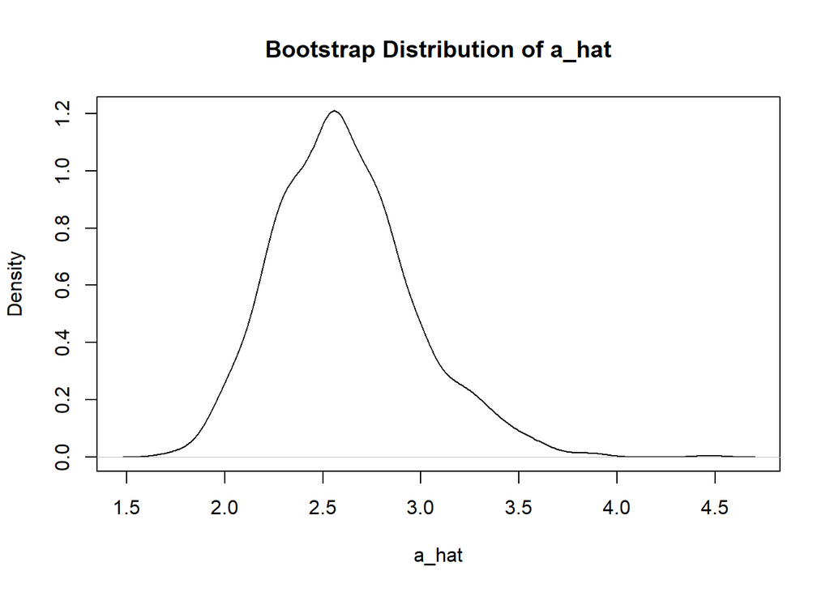

```r
set.seed(123)
B <- 1000 #Number of samples
n <- length(water)

a_boot <- numeric(B) #Creates empty vectors
b_boot <- numeric(B)

for(b in 1:B){
  u <- runif(n) #Generates uniform random numbers
  x_boot <- (1-(1-u)^(1/b_hat))^(1/a_hat) #Inverse of Kumaraswamy CDF
  fit_boot <- optim( #Re-estimates a_hat b_hat using bootstrap sample
    par = c(a_hat, b_hat),
    fn=loglik,
    x=x_boot,
    method="L-BFGS-B",
    lower=c(1e-6, 1e-6)
  )
  a_boot[b] <- fit_boot$par[1] #Stores a_hat and b_hat estimartes
  b_boot[b] <- fit_boot$par[2]
}

plot(density(a_boot), main = "Bootstrap Distribution of a_hat", xlab = "a_hat", ylab="Density") #Plots Guassian kde's
```

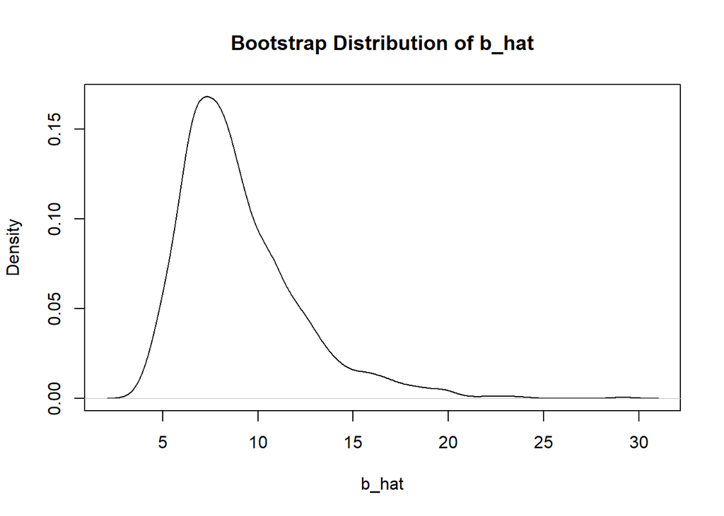

```r
plot(density(b_boot), main="Bootstrap Distribution of b_hat", xlab="b_hat", ylab="Density")
```

(2). Construct both the $95\%$ **bootstrap confidence interval** and the **Wald confidence interval** for $b$. Do these intervals agree with the results obtained in **Problem B2**? [*Compute the standard error of $\hat{b}$ using the observed Fisher information matrix, i.e., the inverse of the negative Hessian obtained from optim()*]